# Assignment 12: Predictive Modeling - Part 3

*How to do it?*:

- Open the Rmarkdown file of this assignment (link) in Rstudio.
- Right under each **question**, insert a code chunk (you can use the hotkey `Ctrl + Alt + I` to add a code chunk) and code the solution for the question.
- `Knit` the rmarkdown file (hotkey: `Ctrl + Alt + K`) to export an html.
- Publish the html file to your Githiub Page.

*Submission*: Submit the link on Github of the assignment to Blackboard.

1. Use the `PimaIndiansDiabetes` dataset. Use 15% data for testing. Use cross-validation with of 7 folds to tune random forest `(method='ranger')`. What are the parameters that produce the greatest accuracy? What is the testing accuracy.

```r
library(mlbench)
library(tidyverse)
library(caret)
data(PimaIndiansDiabetes)
df <- tibble(PimaIndiansDiabetes)
```

```r
#Data Preparation

# Set the target variable
df <- df %>% rename(target=diabetes)

# Handle missing values
df = drop_na(df)

splitIndex <- createDataPartition(df$target, p = .85,
                                  list = FALSE)
df_train <- df[ splitIndex,]
df_test <- df[-splitIndex,]
```

```r
trControl = trainControl(method = "cv",
                         number = 7)

tuneGrid = expand.grid(mtry = 2:4,
                       splitrule = c('gini', 'extratrees'),
                       min.node.size = c(1:10))

forest_ranger <- train(target~., data=df_train,
                    method = "ranger",
                    trControl = trControl,
                    tuneGrid = tuneGrid)
```

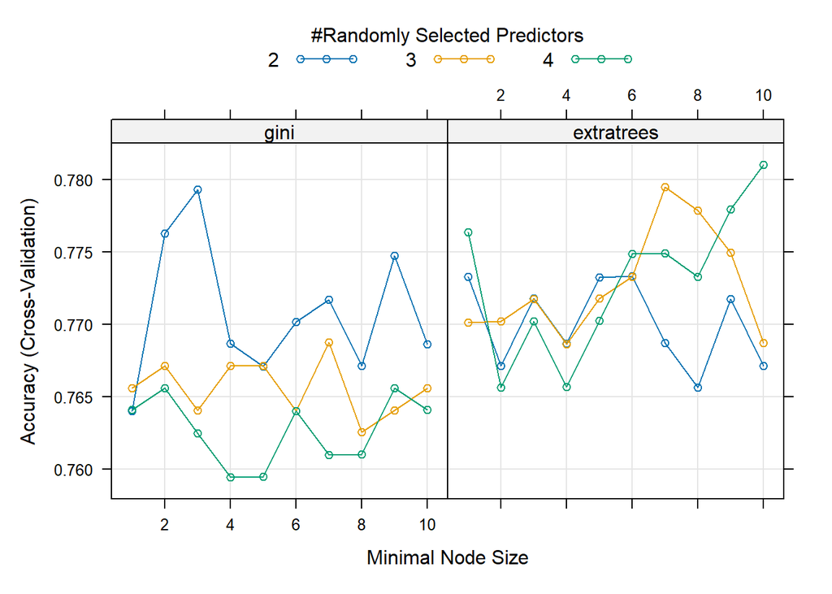

```r
plot(forest_ranger)
```

```r
pred <- predict(forest_ranger, df_test)

cm <- confusionMatrix(data = pred, reference = df_test$target, positive = "pos")

cm$overall[1]
```

```
##  Accuracy
## 0.7478261
```

2. Use the `PimaIndiansDiabetes` dataset. Go to https://topepo.github.io/caret/available-models.html and pick a classification model. Tune the classification model using cross-validation of 7 folds.

```r
tuneGrid = expand.grid(mstop = 2:10, prune = 1)

trControl = trainControl(method = "cv",
                         number = 7)

tree <- train(target~., data=df_train,
                                method = "glmboost",
                                trControl = trControl,
                                tuneGrid = tuneGrid)
```

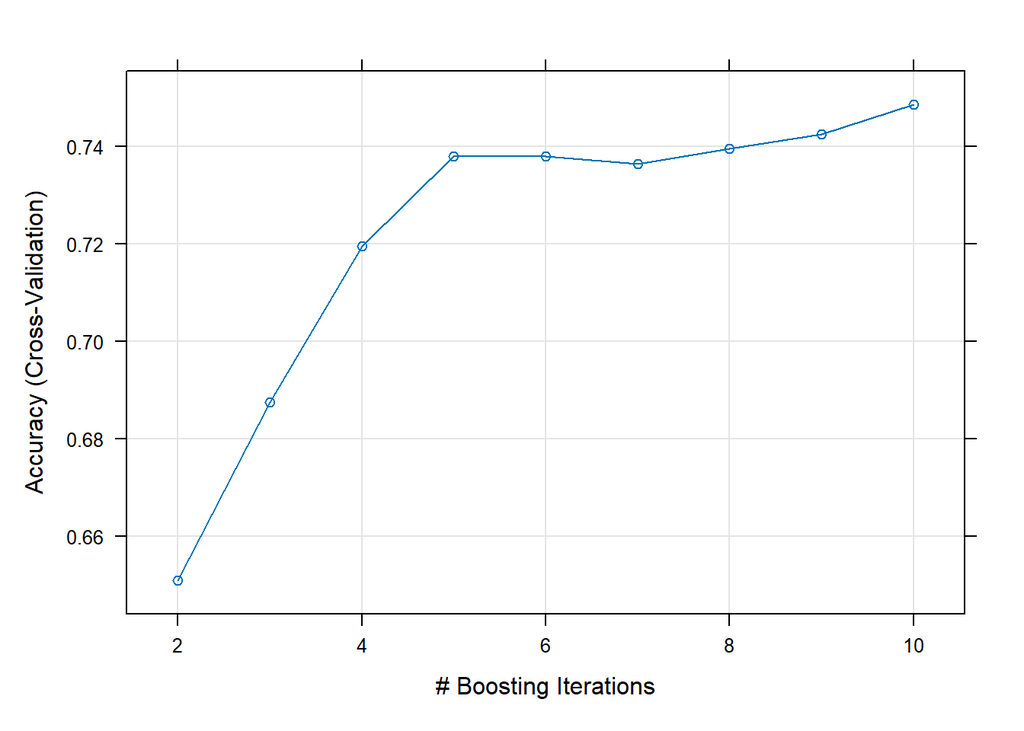

```r
plot(tree)
```

```r
print(tree)
```

```
## Boosted Generalized Linear Model
##
## 653 samples
##   8 predictor
##   2 classes: 'neg', 'pos'
##
## No pre-processing
## Resampling: Cross-Validated (7 fold)
## Summary of sample sizes: 559, 559, 561, 560, 560, 560, ...
## Resampling results across tuning parameters:
##
##   mstop  Accuracy   Kappa
##    2     0.6508531  0.0000000
##    3     0.6875074  0.1477520
##    4     0.7196354  0.2575660
##    5     0.7380526  0.3224984
##    6     0.7380526  0.3251096
##    7     0.7364675  0.3349326
##    8     0.7395731  0.3479214
##    9     0.7425955  0.3580811
##   10     0.7487239  0.3823204
##
## Tuning parameter 'prune' was held constant at a value of 1
## Accuracy was used to select the optimal model using the largest value.
## The final values used for the model were mstop = 10 and prune = 1.
```

```r
pred <- predict(tree, df_test)
cm <- confusionMatrix(data = pred, reference = df_test$target, positive = "pos")
cm$overall[1]
```

```
##  Accuracy
## 0.7652174
```

3. (Model Comparison) Use the `PimaIndiansDiabetes` dataset. Pick two models at [this link](https://topepo.github.io/caret/available-models.html) to compare using 7-fold cross validation method. Evaluate the accuracy of the final model on the test data.

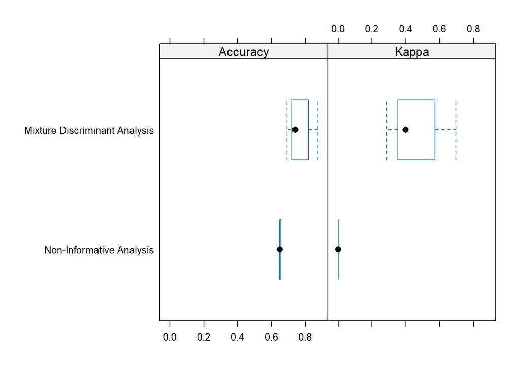

```r
trControl = trainControl(method = "cv",
                         number = 7)

mda <- train(target~., data=df_train,
                                method = "mda",
                                trControl = trControl)

null <- train(target~., data=df_train,
                    method = "null",
                                trControl = trControl)

results <- resamples(list('Mixture Discriminant Analysis' = mda,
                          'Non-Informative Analysis' = null))
bwplot(results)
```

```r
pred <- predict(mda, df_test)
cm <- confusionMatrix(data = pred, reference = df_test$target, positive = "pos")
cm$overall[1]
```

```
##  Accuracy
## 0.7913043
```